# Homework #9: Association Analysis

Siyu Jian / sj9va

Due: Wed Apr 28 | 10:55am

**SYS 4582/6018 | Spring 2021 | University of Virginia**

# Required R packages and Directories

```r
data.dir = 'https://mdporter.github.io/SYS6018/data/' # data directory
library(R6018)     # functions for SYS-6018
library(tidyverse) # functions for data manipulation
library(arules)    # functions for Association Rules
library(readxl)
```

# Problem 1: Interestingness

Suppose we have market basket data consisting of 100 transactions and 20 items. Assume the support for item {$a$} is 20%, support for item {$b$} is 85%, and support for itemset {$a,b$} is 15%.

## a. What is the confidence of the rule {a} $\rightarrow$ {b}?

$$C(a\rightarrow b) = \frac{s(a,b)}{s(a)} = \frac{0.15}{0.2}=0.75$$

## c. Find the *lift* of this rule.

$L(a \rightarrow b) = \frac{0.75}{0.85} =$ 0.8824

## d. Find the *addedValue* of this rule.

$AV(a\rightarrow b) = C(a\rightarrow b) - S(b) = 0.75-0.85 = -0.1$

## e. Find the *leverage/PS* of this rule.

$PS(a\rightarrow b) = S(a,b) - S(a)S(b) = 0.15 - 0.2*0.85=$-0.02

## f. Describe the nature of the relationship between items {a} and {b} according to *lift*, *addedValue* and *leverage/PS*. What observation can you draw from parts (b) and (c-e)?

*lift* $L(a\rightarrow b) = 0.88 < 1$ which indicates negative association (a and b inhibit each other), aka, fewer people are prefered a and b together compare with if a and b is independent. *addedValue* value is smaller than 0, as expected since *left < 1*, it means a and b have negative association. The added value, which is the probabilty of $C(a\rightarrow b) - S(b)$, it shows the probability for get item b also get item a is smaller than the probability of b only, which also indicate an negative association between a and b. Selling on of a/b, does not increase the sale of the other item.

## g. Let $p(a)$, $p(b)$, and $p(a,b)$ be the actual probabilities of observing items {a}, {b}, and {a,b} respectively in a transaction. What is the expected confidence rule {a} $\rightarrow$ {b} if a and b are independent?

if a and b are indepent $Pr(a b) = Pr(a)Pr(b)$

$$C(a\rightarrow b) = \frac{s(a,b)}{s(a)} = \frac{s(a)s(b)}{s(a)} = 0.85$$

# Problem 2: Online Retail

The website http://archive.ics.uci.edu/ml/datasets/online+retail describes some transactional data from an online retailer.

## a. Download the [excel file](http://archive.ics.uci.edu/ml/machine-learning-databases/00352/Online%20Retail.xlsx) to your machine and read it into R.

```r
# check the existant of the file, if not download it from the url
filename = "Online_Retail.xlsx"
if (!file.exists(filename)){
  data.url = "http://archive.ics.uci.edu/ml/machine-learning-databases/00352/Online%20Retail.xlsx"
  download.file(data.url,destfile=filename,method="auto")
}

dataSet = readxl::read_excel(filename)
head(dataSet,10)
```

| InvoiceNo | StockCode | Description | Quantity | InvoiceDate | UnitPrice | CustomerID | Country |
| --- | --- | --- | --- | --- | --- | --- | --- |
| 536365 | 85123A | WHITE HANGING HEART T-LIGHT HOLDER | 6 | 2010-12-01 08:26:00 | 2.55 | 17850 | United Kingdom |
| 536365 | 71053 | WHITE METAL LANTERN | 6 | 2010-12-01 08:26:00 | 3.39 | 17850 | United Kingdom |
| 536365 | 84406B | CREAM CUPID HEARTS COAT HANGER | 8 | 2010-12-01 08:26:00 | 2.75 | 17850 | United Kingdom |
| 536365 | 84029G | KNITTED UNION FLAG HOT WATER BOTTLE | 6 | 2010-12-01 08:26:00 | 3.39 | 17850 | United Kingdom |
| 536365 | 84029E | RED WOOLLY HOTTIE WHITE HEART. | 6 | 2010-12-01 08:26:00 | 3.39 | 17850 | United Kingdom |
| 536365 | 22752 | SET 7 BABUSHKA NESTING BOXES | 2 | 2010-12-01 08:26:00 | 7.65 | 17850 | United Kingdom |
| 536365 | 21730 | GLASS STAR FROSTED T-LIGHT HOLDER | 6 | 2010-12-01 08:26:00 | 4.25 | 17850 | United Kingdom |
| 536366 | 22633 | HAND WARMER UNION JACK | 6 | 2010-12-01 08:28:00 | 1.85 | 17850 | United Kingdom |
| 536366 | 22632 | HAND WARMER RED POLKA DOT | 6 | 2010-12-01 08:28:00 | 1.85 | 17850 | United Kingdom |
| 536367 | 84879 | ASSORTED COLOUR BIRD ORNAMENT | 32 | 2010-12-01 08:34:00 | 1.69 | 13047 | United Kingdom |

## b. There are many quality problems with this dataset, but we will only address two of them. Remove all of the rows with missing Description values (NAs) and remove any duplicate items in a single transaction. Print the first 10 rows of the resulting data.

```r
dataSet = dataSet %>% drop_na(Description)
dataSet = dataSet %>% distinct(InvoiceNo, Description, .keep_all = TRUE)
head(dataSet,10)
```

| InvoiceNo | StockCode | Description | Quantity | InvoiceDate | UnitPrice | CustomerID | Country |
| --- | --- | --- | --- | --- | --- | --- | --- |
| 536365 | 85123A | WHITE HANGING HEART T-LIGHT HOLDER | 6 | 2010-12-01 08:26:00 | 2.55 | 17850 | United Kingdom |
| 536365 | 71053 | WHITE METAL LANTERN | 6 | 2010-12-01 08:26:00 | 3.39 | 17850 | United Kingdom |
| 536365 | 84406B | CREAM CUPID HEARTS COAT HANGER | 8 | 2010-12-01 08:26:00 | 2.75 | 17850 | United Kingdom |
| 536365 | 84029G | KNITTED UNION FLAG HOT WATER BOTTLE | 6 | 2010-12-01 08:26:00 | 3.39 | 17850 | United Kingdom |
| 536365 | 84029E | RED WOOLLY HOTTIE WHITE HEART. | 6 | 2010-12-01 08:26:00 | 3.39 | 17850 | United Kingdom |
| 536365 | 22752 | SET 7 BABUSHKA NESTING BOXES | 2 | 2010-12-01 08:26:00 | 7.65 | 17850 | United Kingdom |
| 536365 | 21730 | GLASS STAR FROSTED T-LIGHT HOLDER | 6 | 2010-12-01 08:26:00 | 4.25 | 17850 | United Kingdom |
| 536366 | 22633 | HAND WARMER UNION JACK | 6 | 2010-12-01 08:28:00 | 1.85 | 17850 | United Kingdom |
| 536366 | 22632 | HAND WARMER RED POLKA DOT | 6 | 2010-12-01 08:28:00 | 1.85 | 17850 | United Kingdom |
| 536367 | 84879 | ASSORTED COLOUR BIRD ORNAMENT | 32 | 2010-12-01 08:34:00 | 1.69 | 13047 | United Kingdom |

## c. Find the number of transactions and number of items using *InvoiceNo* for transactions and *Description* as items (i.e., ignore the *StockCode* column).

```r
NT = length(unique(dataSet$InvoiceNo))
NI = length(unique(dataSet$Description))
```

- number of transactions : 24446
- number of items : 4211

## d. Convert the data frame into a *transaction list* and convert it into a *transactions object* (don’t forget to load the `arules` package). Print a summary (using `summary()`) of the new object.

```r
tList = split(dataSet$Description, dataSet$InvoiceNo)
trans  = as(tList, "transactions")
summary(trans)
```

```
#> transactions as itemMatrix in sparse format with
#>  24446 rows (elements/itemsets/transactions) and
#>  4211 columns (items) and a density of 0.005143
#>
#> most frequent items:
#> WHITE HANGING HEART T-LIGHT HOLDER           REGENCY CAKESTAND 3 TIER
#>                               2302                               2169
#>            JUMBO BAG RED RETROSPOT                      PARTY BUNTING
#>                               2135                               1706
#>            LUNCH BAG RED RETROSPOT                            (Other)
#>                               1607                             519558
#>
#> element (itemset/transaction) length distribution:
#> sizes
#>    1    2    3    4    5    6    7    8    9   10   11   12   13   14   15   16
```

[output cut: 62 more lines]

## e. Find the items with the highest support. Print and plot the support of the top 10.

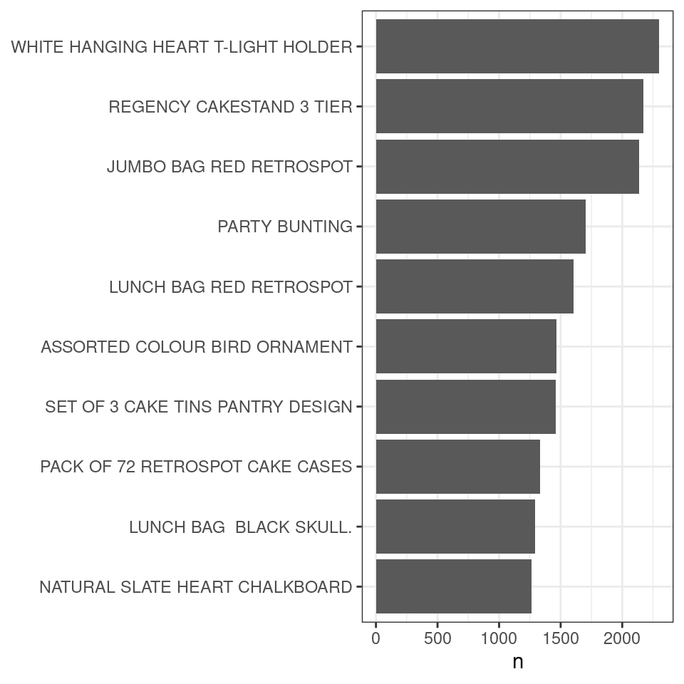

```r
itemFreq = count(dataSet, Description, sort=TRUE) %>% mutate(support=n/NT)
# plot top 10

itemFreq %>% slice(1:10) %>%
  ggplot(aes(fct_reorder(Description, n), n)) + # order bars by n
  geom_col() +         # barplot
  coord_flip() +       # rotate plot 90 deg
  theme(axis.title.y = element_blank()) # remove y axis title
```

```r
itemFreq %>% slice(1:10) %>% knitr::kable()
```

| Description | n | support |
| --- | --- | --- |
| WHITE HANGING HEART T-LIGHT HOLDER | 2302 | 0.0942 |
| REGENCY CAKESTAND 3 TIER | 2169 | 0.0887 |
| JUMBO BAG RED RETROSPOT | 2135 | 0.0873 |
| PARTY BUNTING | 1706 | 0.0698 |
| LUNCH BAG RED RETROSPOT | 1607 | 0.0657 |
| ASSORTED COLOUR BIRD ORNAMENT | 1467 | 0.0600 |
| SET OF 3 CAKE TINS PANTRY DESIGN | 1458 | 0.0596 |
| PACK OF 72 RETROSPOT CAKE CASES | 1334 | 0.0546 |
| LUNCH BAG BLACK SKULL. | 1295 | 0.0530 |
| NATURAL SLATE HEART CHALKBOARD | 1266 | 0.0518 |

## f. Find the *frequent itemsets* that contain at least 3 items and have $s\geq 0.02$. Add the *lift* metric. Show the top 10 results, ordered by *lift*.

```r
?apriori
fis2 = apriori(trans,
              parameter = list(support = .02,minlen=3,target="frequent"))
```

```
#> Apriori
#>
#> Parameter specification:
#>  confidence minval smax arem  aval originalSupport maxtime support minlen
#>          NA    0.1    1 none FALSE            TRUE       5    0.02      3
#>  maxlen            target  ext
#>      10 frequent itemsets TRUE
#>
#> Algorithmic control:
#>  filter tree heap memopt load sort verbose
#>     0.1 TRUE TRUE  FALSE TRUE    2    TRUE
#>
#> Absolute minimum support count: 488
#>
#> set item appearances ...[0 item(s)] done [0.00s].
#> set transactions ...[4211 item(s), 24446 transaction(s)] done [0.15s].
#> sorting and recoding items ... [202 item(s)] done [0.00s].
#> creating transaction tree ... done [0.01s].
#> checking subsets of size 1 2 3 done [0.00s].
#> sorting transactions ... done [0.00s].
#> writing ... [1 set(s)] done [0.00s].
#> creating S4 object  ... done [0.00s].
```

```r
apriori2df(fis2) %>% arrange(-support)  # order by support (largest to smallest)
```

| items | support | transIdenticalToItemsets | count |
| --- | --- | --- | --- |
| {GREEN REGENCY TEACUP AND SAUCER,PINK REGENCY TEACUP AND SAUCER,ROSES REGENCY TEACUP AND SAUCER} | 0.02246 | 0.0009408 | 549 |

```r
#-- Add lift using the interestMeasure() function
result.f = apriori2df(fis2) %>%
  mutate(lift = interestMeasure(fis2, measure="lift", trans)) %>%
  arrange(-lift)

head(result.f,10)
```

| items | support | transIdenticalToItemsets | count | lift |
| --- | --- | --- | --- | --- |
| {GREEN REGENCY TEACUP AND SAUCER,PINK REGENCY TEACUP AND SAUCER,ROSES REGENCY TEACUP AND SAUCER} | 0.02246 | 0.0009408 | 549 | 346 |

## g. Find all of the *association rules* with $s \geq 0.02$, $c \geq 0.70$. Add the *PS/leverage* and *addedValue* metrics. Show all results, ordered by *addedValue*

```r
rules = apriori(trans,
             parameter = list(support=.02, confidence=.70,
                              minlen=2,target="rules"))
```

```
#> Apriori
#>
#> Parameter specification:
#>  confidence minval smax arem  aval originalSupport maxtime support minlen
#>         0.7    0.1    1 none FALSE            TRUE       5    0.02      2
#>  maxlen target  ext
#>      10  rules TRUE
#>
#> Algorithmic control:
#>  filter tree heap memopt load sort verbose
#>     0.1 TRUE TRUE  FALSE TRUE    2    TRUE
#>
#> Absolute minimum support count: 488
#>
#> set item appearances ...[0 item(s)] done [0.00s].
#> set transactions ...[4211 item(s), 24446 transaction(s)] done [0.14s].
#> sorting and recoding items ... [202 item(s)] done [0.00s].
#> creating transaction tree ... done [0.01s].
#> checking subsets of size 1 2 3 done [0.00s].
#> writing ... [8 rule(s)] done [0.00s].
#> creating S4 object  ... done [0.00s].
```

```r
apriori2df(rules) %>%
  mutate(addedValue = interestMeasure(rules, measure="addedValue", trans),
         PS = interestMeasure(rules, measure="leverage", trans)) %>%
  arrange(-addedValue) %>% knitr::kable()
```

| lhs | rhs | support | confidence | coverage | lift | count | addedValue | PS |
| --- | --- | --- | --- | --- | --- | --- | --- | --- |
| {PINK REGENCY TEACUP AND SAUCER,ROSES REGENCY TEACUP AND SAUCER} | {GREEN REGENCY TEACUP AND SAUCER} | 0.0225 | 0.8941 | 0.0251 | 20.68 | 549 | 0.8509 | 0.0214 |
| {GREEN REGENCY TEACUP AND SAUCER,PINK REGENCY TEACUP AND SAUCER} | {ROSES REGENCY TEACUP AND SAUCER} | 0.0225 | 0.8525 | 0.0263 | 18.61 | 549 | 0.8067 | 0.0213 |
| {PINK REGENCY TEACUP AND SAUCER} | {GREEN REGENCY TEACUP AND SAUCER} | 0.0263 | 0.8040 | 0.0328 | 18.59 | 644 | 0.7608 | 0.0249 |
| {PINK REGENCY TEACUP AND SAUCER} | {ROSES REGENCY TEACUP AND SAUCER} | 0.0251 | 0.7665 | 0.0328 | 16.73 | 614 | 0.7207 | 0.0236 |
| {GREEN REGENCY TEACUP AND SAUCER} | {ROSES REGENCY TEACUP AND SAUCER} | 0.0321 | 0.7417 | 0.0432 | 16.19 | 784 | 0.6959 | 0.0301 |
| {GARDENERS KNEELING PAD CUP OF TEA} | {GARDENERS KNEELING PAD KEEP CALM} | 0.0225 | 0.7176 | 0.0313 | 18.99 | 549 | 0.6798 | 0.0213 |
| {GREEN REGENCY TEACUP AND SAUCER,ROSES REGENCY TEACUP AND SAUCER} | {PINK REGENCY TEACUP AND SAUCER} | 0.0225 | 0.7003 | 0.0321 | 21.37 | 549 | 0.6675 | 0.0214 |
| {ROSES REGENCY TEACUP AND SAUCER} | {GREEN REGENCY TEACUP AND SAUCER} | 0.0321 | 0.7000 | 0.0458 | 16.19 | 784 | 0.6568 | 0.0301 |

## h. Find one rule that you think is interesting. Write the rule and explain why you find it interesting.

I think {PINK REGENCY TEACUP AND SAUCER} and {GREEN REGENCY TEACUP AND SAUCER} is interesting They have a big addedvalue, which indicate they have positive($0.7608$) association and often buy together. From my experience, I would like to choose the same color saucer to make it consistent, while it seems like so many people prefer choose mixed colors in there homes.